# Measuring impact of model assumptions in binary black hole simuations -

## Initial Hypothesis and Prediction -

**Hypothesis** - Analyzing the data, we see that the change in the properties of two black holes occur independent of each other. In other words, we assume that the change in black hole mass and spin only depends on the infall of radiation into black hole's surface and is not affected by the presence of nearby black hole in any way. Hence, we can approximate each black hole to be in isolated state.

**Prediction** - Model of isolated black hole should also predict similar changes in mass and spins as seen for black holes in binary.

## Testing -

To test this hypothesis, we perform around 120 simulations of single black hole for varying spin and initial speed using the same data method. After some initial analysis, we compute the changes in mass and spin of black hole for each case. Using a fifth order polynomial fitting, we are able to show that change in mass and spin show polynomial behavior as a function of initial spin and initial speed.

```python
import ipywidgets as widgets
import IPython.display as display

def embed_image(img1_file, img2_file):

    img1 = open(img1_file, 'rb').read()
    img2 = open(img2_file, 'rb').read()

    wi1 = widgets.Image(value=img1, format='png', width=600, height=800)
    wi2 = widgets.Image(value=img2, format='png', width=600, height=800)
    ## Side by side thanks to HBox widgets
    sidebyside = widgets.HBox([wi1, wi2])
    ## Finally, show.
    display.display(sidebyside)

irrmass_err = '../junk-radiation/Paper/Figures/BK_Figures/Figure4.png'
spin_err = '../junk-radiation/Paper/Figures/BK_Figures/Figure6.png'

embed_image(irrmass_err, spin_err)
```

[output not shown]

## Testing (cont.)

```python
import ipywidgets as widgets
import IPython.display as display

def embed_image(img1_file, img2_file):

    img1 = open(img1_file, 'rb').read()
    img2 = open(img2_file, 'rb').read()

    wi1 = widgets.Image(value=img1, format='png', width=600, height=800)
    wi2 = widgets.Image(value=img2, format='png', width=600, height=800)
    ## Side by side thanks to HBox widgets
    sidebyside = widgets.HBox([wi1, wi2])
    ## Finally, show.
    display.display(sidebyside)

irrmass_err = '../junk-radiation/Paper/Figures/BK_Figures/Figure8.png'
irrmass_res = '../junk-radiation/Paper/Figures/BK_Figures/Figure9.png'
embed_image(irrmass_err, irrmass_res)
## Read images from file (because this is binary, maybe you can find how to use ByteIO) but this is more easy
## Create image widgets. You can use layout of ipywidgets only with widgets.
## Set image variable, image format and dimension.

spin_err = '../junk-radiation/Paper/Figures/BK_Figures/Figure10.png'
spin_res = '../junk-radiation/Paper/Figures/BK_Figures/Figure11.png'
embed_image(spin_err, spin_res)
```

[output not shown]

## Model Correction -

The modifications in source properties are undesirable and affects the validity of the model. In particular, it would be preferred if we could specify the initial state of the system in its relaxed state after passing the junk radiation. This would account for mass and spin changes from artificial radiation and ensure we are modeling the true state.

Here, we devise a new method based on above methods. We start with desired configuration of the binary parameters described by masses $M_1, M_2$ and spin magnitudes $\vec{a}_1, \vec{a}_2$. Then, at $t=0$, the configuration of the binary can be determined by solving the following equations -

$$ M_i = [1 + \delta \bar{M}_i \,(\bar{a}_i, v_i)]\,\bar{M}_i$$ $$ a_i = [1 + \delta \bar{a}_i \,(\bar{a}_i, v_i)]\,\bar{a}_i$$

Here, $\bar{M}_i$ and $\bar{a}_i$ are the masses and spin magnitudes of $i^{th}$ black hole at initial time. The above equations can be solved using Newton's method. Below, we show the gravitational wave signatures from the original and the corrected initial data for spin magnitudes of 0.6 and 0.8 using this method. As can be seen, the waveform signatures are clearly different.

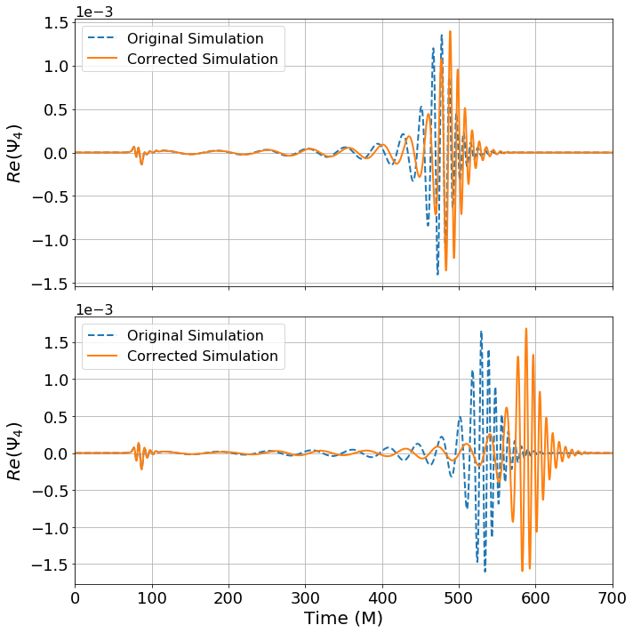

```python
# GW signatures of original and corrected simulation

os.chdir('/localdata2/bkhamesra3/simulations/BBH/Comet/JunkRadiation/BBH/GenerateStrain/WFSummaryDirectory/')

#Read the data

t1, re1, im1 = np.loadtxt('./BBH_JK_q1_a0.6_M150-all/Ylm_WEYLSCAL4::Psi4r_l2_m2_r75.00.asc', unpack=True, usecols=(0,1,2))
t2, re2, im2 = np.loadtxt('./BBH_JK_q1_a0.6_M150_IDUpdated_Fits-all/Ylm_WEYLSCAL4::Psi4r_l2_m2_r75.00.asc', unpack=True, usecols=(0,1,2))

t3, re3, im3 = np.loadtxt('./BBH_JK_q1_a0.8_M150-all/Ylm_WEYLSCAL4::Psi4r_l2_m2_r75.00.asc', unpack=True, usecols=(0,1,2))
t4, re4, im4 = np.loadtxt('./BBH_JK_q1_a0.8_M150_IDUpdated_Fits-all/Ylm_WEYLSCAL4::Psi4r_l2_m2_r75.00.asc', unpack=True, usecols=(0,1,2))


#Plot the results
fig, (ax1,ax2)=plt.subplots(2,1,figsize=(10,10), sharex=True)
plt.subplots_adjust(wspace=0, hspace=0.05)
ax1.plot(t1, re1, ls='--',label='Original Simulation')
ax1.plot(t2, re2, label='Corrected Simulation')
#ax1.set_xlabel('Time')
ax1.set_ylabel(r'$Re(\Psi_4)$', fontsize=20)
ax1.set_xlim(0,700)
ax1.ticklabel_format(style='sci', scilimits=(0,3))
ax1.tick_params(axis='both',labelsize=18)

ax1.legend()


ax2.plot(t3, re3, ls='--',label='Original Simulation')
ax2.plot(t4, re4, label='Corrected Simulation')
ax2.set_xlabel('Time (M)', fontsize=20)
ax2.set_ylabel(r'$Re(\Psi_4)$', fontsize=20)
ax2.set_xlim(0,700)
ax2.ticklabel_format(style='sci', scilimits=(0,3))
ax2.tick_params(axis='both',labelsize=18)


ax2.legend()
plt.tight_layout()
plt.show()
plt.close()
```

## Publication Link -

The results of this work were published in Physical Review D - https://journals.aps.org/prd/abstract/10.1103/PhysRevD.100.081501

For access for data, codes or any other questions, you can reach out to me at bhaveshkhamesra@gatech.edu